# IR analysis for crude characterization

## Step 1: Organizing the data

For the cluster analysis it is important to first scale the data in order to remove the bias for cluster analysis and principal componenet analysis.

```r
setwd("C:/Users/Abhishek/Desktop/EACH/Computing/IR Data Analysis")
VR<- read.csv("VR.csv", header = T)
s<- as.matrix(VR[,1])
VR_new <- VR[,-1]
rownames(VR_new)<- s
VR_scaled<- as.data.frame(scale(VR_new))
```

## Perfoming cluster analysis using K-Means

Here the overall dataset is divided into 5 meaningful cluster which is classified as 1. Extra-heavy residues 2. Heavy residues 3. Light condensates 4. Medium residues 5. Heavy condensates

The clust plot shows that spectral properties of each cluster has the similar order and hence behaves similarly.

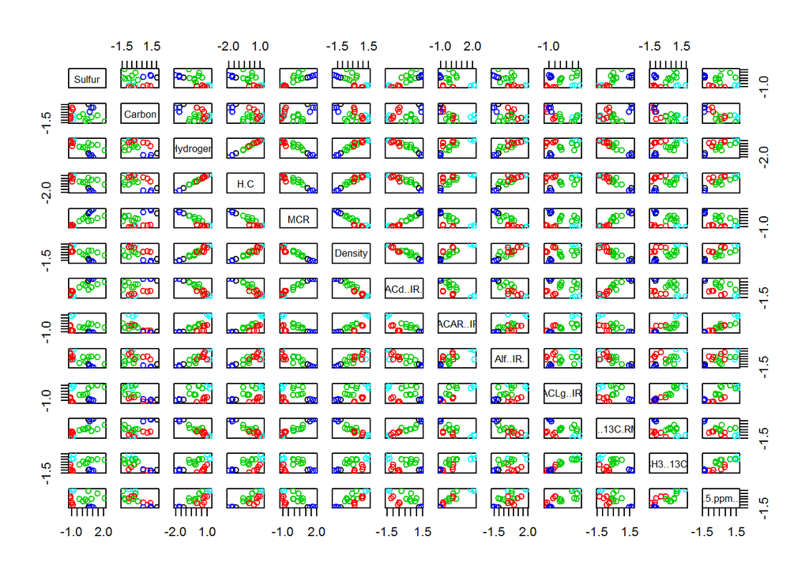

```r
c1 <- kmeans(VR_scaled, 5)
plot(VR_scaled, col=c1$cluster)
```

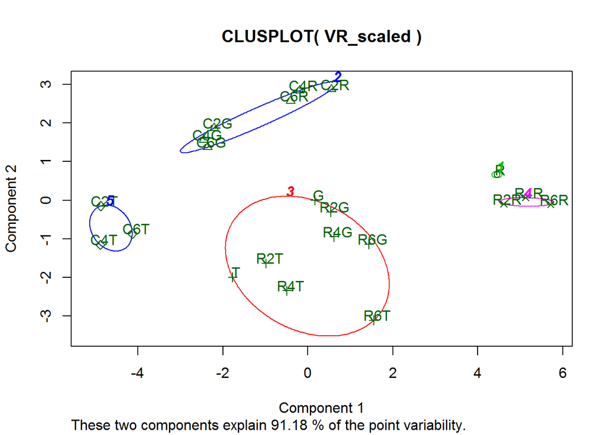

```r
library(cluster)
clusplot(VR_scaled, c1$cluster, color=TRUE, labels=2, lines=0)
```

## Performing principal component analysis

Now, PCA is done to reduce the dimensitionality to a meaningful dimension which can explain the overall variability and the correlation between any dimesional vector on pricipal componenet plot through loading and score plot. Screeplot expains the variance of each pricipal component. From the screeplot it can said that PC1 & PC2 has variance greater than 1 and it expains the maximum variability then other PCs.

```r
pca1<-princomp(VR_scaled, scores = T, cor = T)
summary(pca1)
```

```
## Importance of components:
##                           Comp.1    Comp.2     Comp.3     Comp.4
## Standard deviation     3.0183025 1.6564681 0.69056220 0.50022245
## Proportion of Variance 0.7007807 0.2110682 0.03668278 0.01924788
## Cumulative Proportion  0.7007807 0.9118489 0.94853173 0.96777961
##                            Comp.5      Comp.6      Comp.7      Comp.8
## Standard deviation     0.43451344 0.315282126 0.246470290 0.170283101
## Proportion of Variance 0.01452323 0.007646371 0.004672893 0.002230487
## Cumulative Proportion  0.98230284 0.989949208 0.994622101 0.996852588
##                             Comp.9      Comp.10     Comp.11      Comp.12
## Standard deviation     0.156403320 0.1073823198 0.061385711 3.300642e-02
## Proportion of Variance 0.001881692 0.0008869971 0.000289862 8.380185e-05
## Cumulative Proportion  0.998734280 0.9996212775 0.999911139 9.999949e-01
##                             Comp.13
## Standard deviation     8.109403e-03
## Proportion of Variance 5.058648e-06
## Cumulative Proportion  1.000000e+00
```

```r
loadings(pca1)
```

```
##
## Loadings:
##                         Comp.1 Comp.2 Comp.3 Comp.4 Comp.5 Comp.6 Comp.7
## Sulfur                   0.205 -0.444         0.229 -0.499 -0.259 -0.242
## Carbon                   0.200  0.320 -0.831  0.136 -0.322         0.134
## Hydrogen                -0.320  0.101               -0.389         0.262
## H.C                     -0.323                      -0.369         0.248
## MCR                      0.299 -0.242 -0.101         0.210         0.161
## Density                 -0.326                             -0.141 -0.265
## ACd..IR.                 0.308 -0.201         0.134 -0.120  0.277  0.166
## LACAR..IR.              -0.287 -0.204 -0.442 -0.176  0.403        -0.252
## Alf..IR.                -0.289                0.920  0.187
## ACLg..IR.               -0.180 -0.490 -0.215        -0.242        -0.395
## fah..13C.RMN.            0.311 -0.142 -0.108  0.127  0.181 -0.556  0.221
## CH2.CH3..13C.RMN.       -0.202 -0.458 -0.120                0.499  0.438
## Area.1.1.5.ppm..1H.RMN. -0.293 -0.246                      -0.515  0.456
##                         Comp.8 Comp.9 Comp.10 Comp.11 Comp.12 Comp.13
## Sulfur                   0.103  0.229 -0.432  -0.103  -0.254
## Carbon                          0.128
## Hydrogen                       -0.374                 -0.221  -0.671
## H.C                            -0.371                          0.723
## MCR                      0.414 -0.426 -0.119  -0.592   0.214
## Density                 -0.230  0.318  0.303  -0.739
## ACd..IR.                               0.628          -0.563
## LACAR..IR.                     -0.221 -0.218          -0.560
## Alf..IR.                       -0.122
## ACLg..IR.                      -0.281  0.383   0.226   0.425
## fah..13C.RMN.           -0.643 -0.213
## CH2.CH3..13C.RMN.       -0.333  0.325 -0.213           0.149
## Area.1.1.5.ppm..1H.RMN.  0.461  0.273  0.242   0.118
##
##                Comp.1 Comp.2 Comp.3 Comp.4 Comp.5 Comp.6 Comp.7 Comp.8
## SS loadings     1.000  1.000  1.000  1.000  1.000  1.000  1.000  1.000
## Proportion Var  0.077  0.077  0.077  0.077  0.077  0.077  0.077  0.077
## Cumulative Var  0.077  0.154  0.231  0.308  0.385  0.462  0.538  0.615
##                Comp.9 Comp.10 Comp.11 Comp.12 Comp.13
## SS loadings     1.000   1.000   1.000   1.000   1.000
## Proportion Var  0.077   0.077   0.077   0.077   0.077
## Cumulative Var  0.692   0.769   0.846   0.923   1.000
```

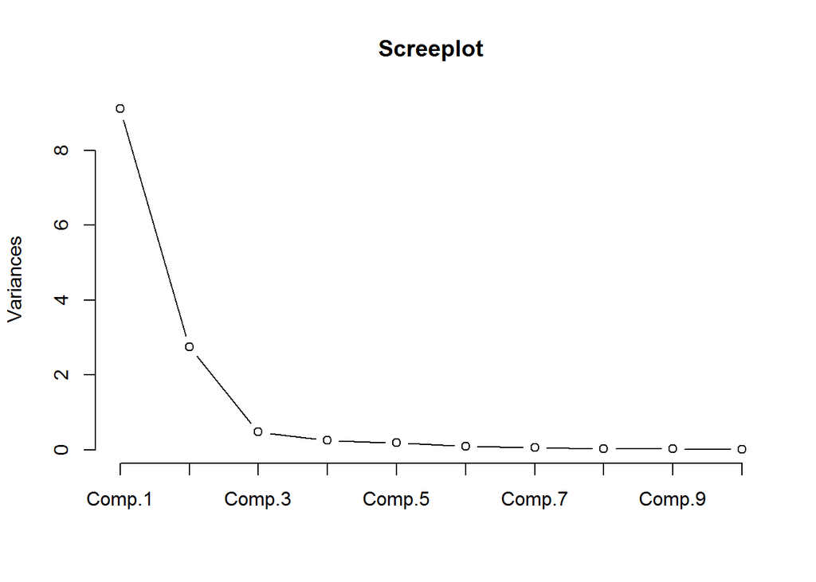

```r
screeplot(pca1, type ="lines", main = "Screeplot")
```

# Getting the biplot

This explain the loading and score of the overall dataset in the two dimensional principal components 1 & 2 which defines the maximum variability.

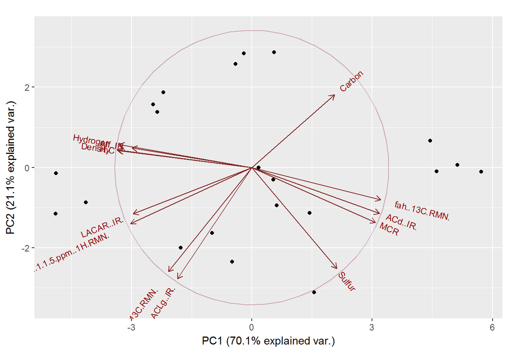

```r
library(ggbiplot)
g <- ggbiplot(pca1, obs.scale = 1, var.scale = 1,
              ellipse = TRUE,
              circle = TRUE)
g <- g + scale_color_discrete(name = '')
g <- g + theme(legend.direction = 'horizontal',
               legend.position = 'top')
print(g)
```

```r
pca1$loadings
```

```
##
## Loadings:
##                         Comp.1 Comp.2 Comp.3 Comp.4 Comp.5 Comp.6 Comp.7
## Sulfur                   0.205 -0.444         0.229 -0.499 -0.259 -0.242
## Carbon                   0.200  0.320 -0.831  0.136 -0.322         0.134
## Hydrogen                -0.320  0.101               -0.389         0.262
## H.C                     -0.323                      -0.369         0.248
## MCR                      0.299 -0.242 -0.101         0.210         0.161
## Density                 -0.326                             -0.141 -0.265
## ACd..IR.                 0.308 -0.201         0.134 -0.120  0.277  0.166
## LACAR..IR.              -0.287 -0.204 -0.442 -0.176  0.403        -0.252
## Alf..IR.                -0.289                0.920  0.187
## ACLg..IR.               -0.180 -0.490 -0.215        -0.242        -0.395
## fah..13C.RMN.            0.311 -0.142 -0.108  0.127  0.181 -0.556  0.221
## CH2.CH3..13C.RMN.       -0.202 -0.458 -0.120                0.499  0.438
## Area.1.1.5.ppm..1H.RMN. -0.293 -0.246                      -0.515  0.456
##                         Comp.8 Comp.9 Comp.10 Comp.11 Comp.12 Comp.13
## Sulfur                   0.103  0.229 -0.432  -0.103  -0.254
## Carbon                          0.128
## Hydrogen                       -0.374                 -0.221  -0.671
## H.C                            -0.371                          0.723
## MCR                      0.414 -0.426 -0.119  -0.592   0.214
## Density                 -0.230  0.318  0.303  -0.739
## ACd..IR.                               0.628          -0.563
## LACAR..IR.                     -0.221 -0.218          -0.560
## Alf..IR.                       -0.122
## ACLg..IR.                      -0.281  0.383   0.226   0.425
## fah..13C.RMN.           -0.643 -0.213
## CH2.CH3..13C.RMN.       -0.333  0.325 -0.213           0.149
## Area.1.1.5.ppm..1H.RMN.  0.461  0.273  0.242   0.118
##
##                Comp.1 Comp.2 Comp.3 Comp.4 Comp.5 Comp.6 Comp.7 Comp.8
## SS loadings     1.000  1.000  1.000  1.000  1.000  1.000  1.000  1.000
## Proportion Var  0.077  0.077  0.077  0.077  0.077  0.077  0.077  0.077
## Cumulative Var  0.077  0.154  0.231  0.308  0.385  0.462  0.538  0.615
##                Comp.9 Comp.10 Comp.11 Comp.12 Comp.13
## SS loadings     1.000   1.000   1.000   1.000   1.000
## Proportion Var  0.077   0.077   0.077   0.077   0.077
## Cumulative Var  0.692   0.769   0.846   0.923   1.000
```

# Making the multiple linear regression model for density and MCR

The MLR model is built based on the PCA dependency. The model is not cross validated here based on training set and test set.

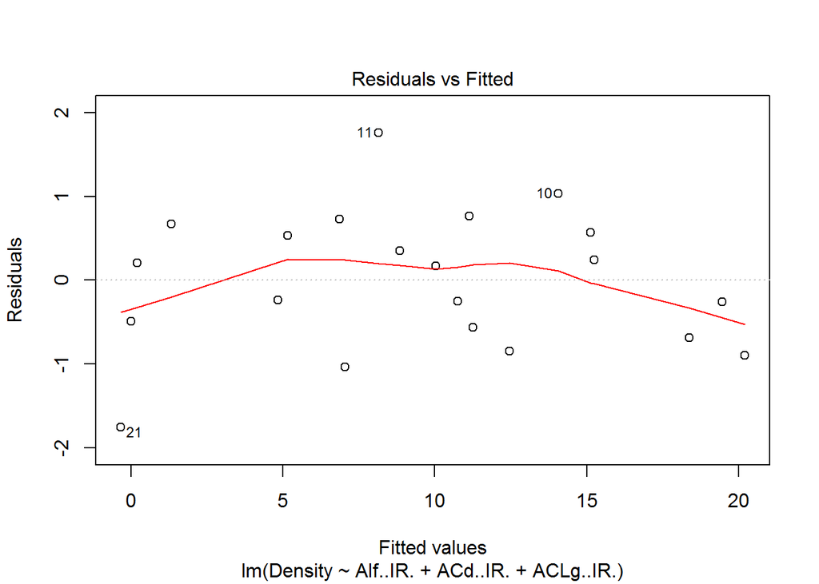

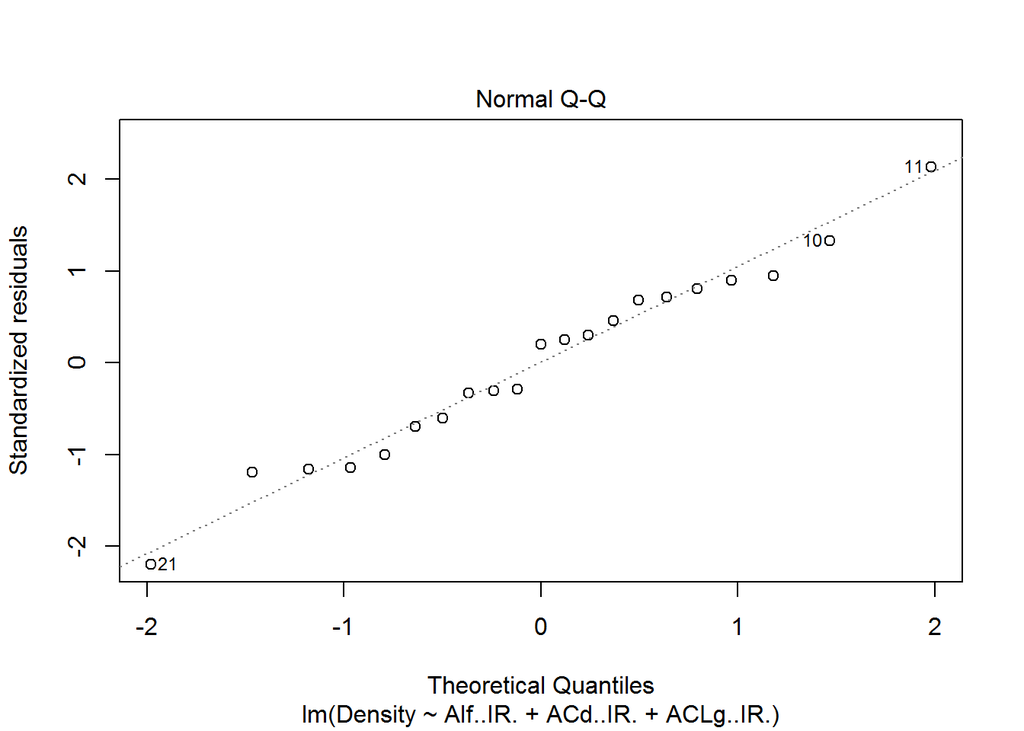

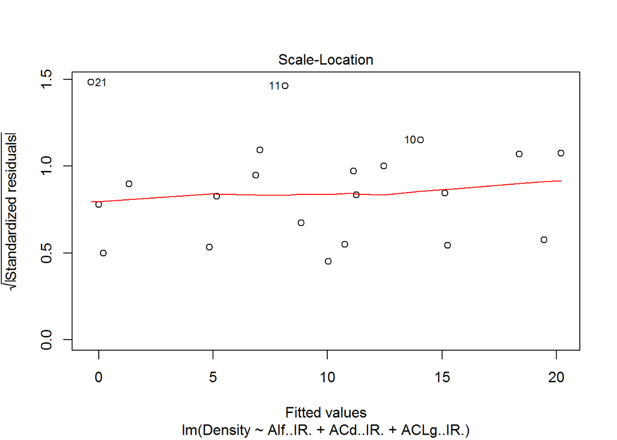

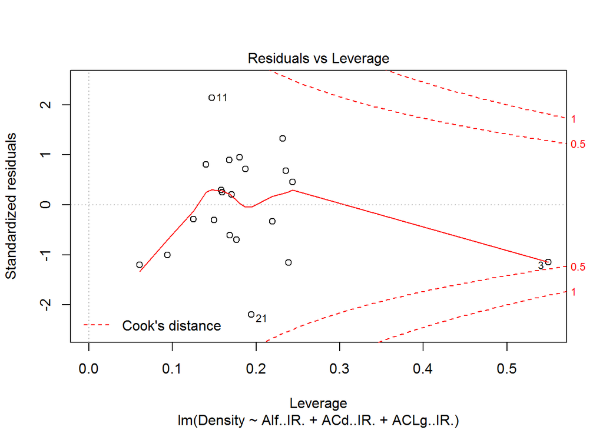

```r
Model_Density <- lm(Density~ Alf..IR.+ ACd..IR. + ACLg..IR., data=VR)
plot(Model_Density)
```

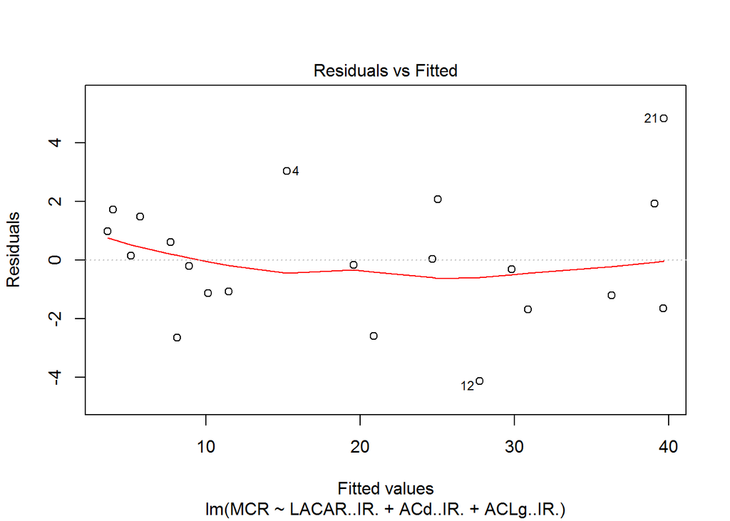

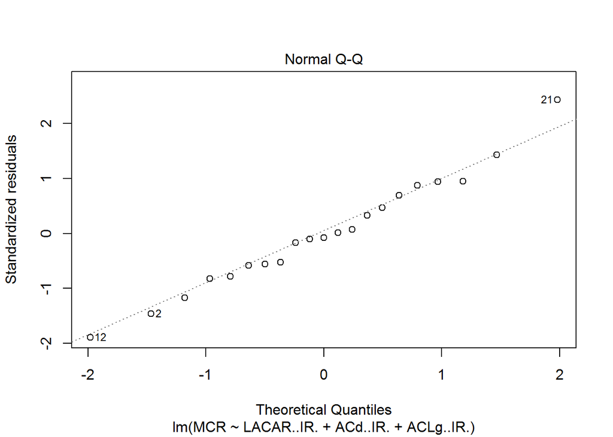

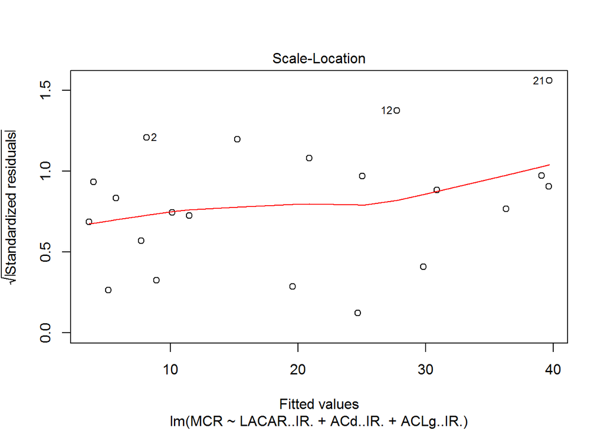

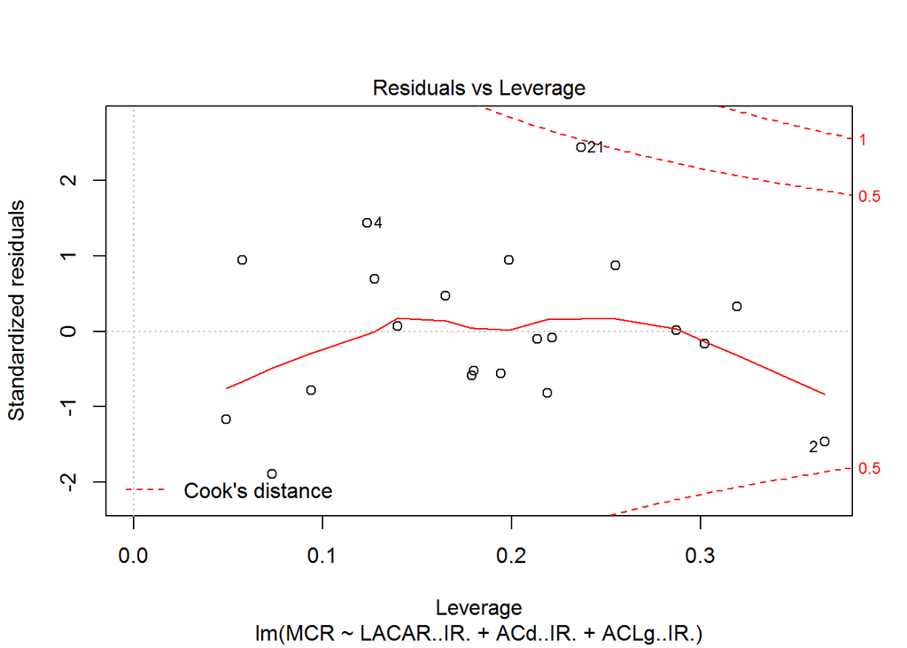

```r
Model_MCR <- lm(MCR~ LACAR..IR.+ ACd..IR. + ACLg..IR., data=VR)
plot(Model_MCR)
```